# Stanford Psychology Climate Survey: 2018-2019

Lucy King

# Goal

The goal of the Psychology Department Climate Survey is provide the department with insights into feelings of inclusion and equality (or lack thereof) within the graduate student, postdoc, and research staff population. This information will inform efforts to cultivate an inclusive community that values diverse questions, viewpoints, approaches, and participant samples to foster ingenuity, challenge biases, and promote intellectual growth. Further, this information will inform possible actions to foster individual and collective wellbeing, which is requisite for academic success.

# Method

In Summer 2019, graduate students, postdoctoral fellows, and research staff were emailed an online link to complete the Climate Survey (a PDF of the survey is available on the Psychology Graduate Students Google Drive in the “Climate Survey” folder).

The survey included questions about feelings of belonging uncertainty, stereotype threat (i.e., concerns about negative judgement due to identity), contextual threat (i.e., beliefs and experiences of bias and discrimination), beliefs about collective action (i.e., beliefs that others value increasing inclusivity), and gender dynamics (i.e., concerns about issues surrounding gender identity and harassment). In addition, we collected information concerning participation in the Diversity Committee (i.e., past participation and interest). We asked minimal demographics questions to avoid identifiability within the relatively small sample, emphasizing that these questions were optional.

# Participants

| position | n | proportion |
| --- | --- | --- |
| Graduate student | 27 | 0.4500000 |
| Postdoctoral fellow | 7 | 0.1166667 |
| Research staff member | 11 | 0.1833333 |
| NA | 15 | 0.2500000 |

| gender | n | proportion |
| --- | --- | --- |
| Female | 30 | 0.5000000 |
| Male | 16 | 0.2666667 |
| NA | 14 | 0.2333333 |

| minority | n | proportion |
| --- | --- | --- |
| No | 27 | 0.45 |
| Yes | 18 | 0.30 |
| NA | 15 | 0.25 |

We received 60 response to the survey. We included optional questions about position in the department (graduate student, postdoc, research staff), gender identity (female, male, other/non-binary), and identity as an underrepresented minority. Among participants who responded, the majority (N = 27) were graduate students, followed by research staff (N = 11), and postdoctoral fellows (N = 7). In terms of gender, approximately twice as many participants identified as female (N = 30) compared to male (N = 16), indicating an imbalance in participation, although it is possible that a larger proportion of the group who did not respond to the demographic questions was male. No one identified their gender as “other/non-binary.” Finally, 18 participants identified as an underrepresented minority.

# Results

## Belonging uncertainty

### When you think about the psychology department, how often, if ever, do you wonder: “maybe I don’t belong here?”

| d_belong | n | proportion |
| --- | --- | --- |
| Sometimes | 30 | 0.50000000 |
| Hardly ever | 17 | 0.28333333 |
| Frequently | 10 | 0.16666667 |
| Never | 2 | 0.03333333 |
| Always | 1 | 0.01666667 |

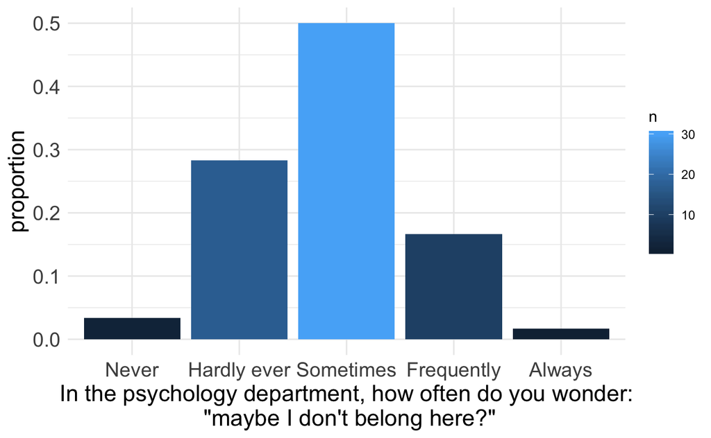

| minority_text | d_belong | n | proportion |
| --- | --- | --- | --- |
| Non-minority | Sometimes | 12 | 0.44444444 |
| Non-minority | Hardly ever | 9 | 0.33333333 |
| Non-minority | Frequently | 4 | 0.14814815 |
| Non-minority | Always | 1 | 0.03703704 |
| Non-minority | Never | 1 | 0.03703704 |
| Minority | Sometimes | 10 | 0.55555556 |
| Minority | Frequently | 4 | 0.22222222 |
| Minority | Hardly ever | 3 | 0.16666667 |
| Minority | Never | 1 | 0.05555556 |
| No response | Sometimes | 8 | 0.53333333 |

[output cut: 2 more lines]

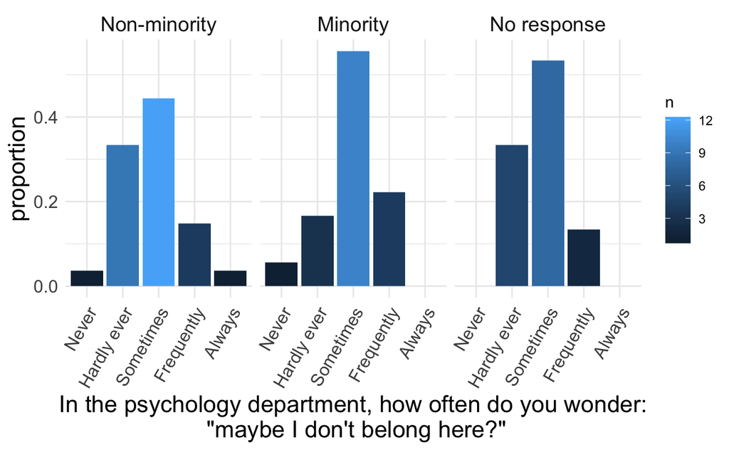

### When you think about the academic research community in your field, how often, if ever, do you wonder: “maybe I don’t belong here?”

| a_belong | n | proportion |
| --- | --- | --- |
| Sometimes | 30 | 0.5000000 |
| Frequently | 20 | 0.3333333 |
| Hardly ever | 10 | 0.1666667 |